# Statistical inference and estimation

307312 Applied Statistics — Masters Level

Read each topic and run the **Try this in R** examples beside it.

- Open the top-level course folder in Positron and keep the R Console at that project root.
- Run the R cells in order; later comparisons and regression checks reuse the data and models introduced earlier.
- Complete Probability foundations first. CSVs are supplied under `data/inferential-statistics/`. Install the recommended R package MASS if needed for the distribution-fitting example.

## 4.1 Statistical inference and estimation

### Content

- **Statistical inference:** populations, samples, parameters and statistics.
- **Sampling distributions and standard error:** how estimates vary across random samples.
- **Central limit theorem:** when a normal approximation for the sample mean is justified.
- **Estimation:** point estimates, confidence intervals, normal and t methods, and sample size.
- **Hypothesis testing:** hypotheses, significance, p-values and comparisons.
- **Regression:** linear models, interpretation and diagnostics.

### Introduction to Inferential Statistics

**Definition**: Inferential statistics is the branch of statistics that involves making inferences or predictions about a population based on sample data.

**Objective**: The main goal of inferential statistics is to draw conclusions, make predictions, or test hypotheses about a population using information obtained from a sample.

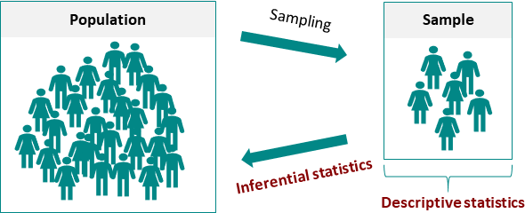

### Inferential Statistics Uses

Inferential statistics is used in various fields and contexts to make predictions, draw conclusions, and make inferences about populations based on sample data. Here are some common areas and applications where inferential statistics is used:

**Scientific Research**: Inferential statistics is fundamental in scientific research across disciplines such as biology, physics, chemistry, and environmental science. Researchers use statistical tests to analyze data and draw conclusions about hypotheses.

**Business and Economics**: Businesses use inferential statistics for market research, sales forecasting, quality control, and decision-making. Econometric models are employed to analyze economic data and make policy recommendations.

**Healthcare and Medicine**: Medical researchers and healthcare professionals use inferential statistics to study the effectiveness of treatments, analyze patient data, and draw conclusions about disease prevalence. Clinical trials rely heavily on inferential statistics.

**Education**: In the field of education, inferential statistics are used to assess the effectiveness of teaching methods, evaluate standardized test scores, and make policy decisions about educational programs.

**Market Research and Data Analysis**: Market researchers use inferential statistics to make predictions about consumer preferences, market trends, and the impact of marketing campaigns.

**Finance and Investment**: In finance, inferential statistics are used to assess investment risk, analyze stock market data, and estimate future asset prices. Portfolio optimization and risk management rely on statistical modeling.

**Criminal Justice and Criminology**: Researchers and law enforcement agencies use inferential statistics to analyze crime data, study crime patterns, and evaluate the effectiveness of criminal justice programs.

**Sports and Athletics**: In sports analytics, inferential statistics are used to analyze player performance, predict game outcomes, and make strategic decisions in sports management.

### Introduction to Inferential Statistics

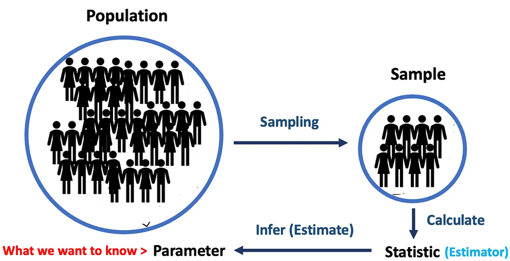

**Key** **Concepts**:

**Population**: The entire group of individuals or items of interest that we want to study.

**Sample**: A subset of the population from which data is collected and analyzed.

**Parameter**: A numerical characteristic of a population (e.g., mean, proportion).

**Statistic**: A numerical characteristic of a sample (e.g., sample mean, sample proportion).

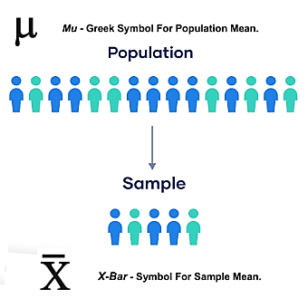

**Background reading — p-values**

Further reading on p-values, used in hypothesis testing.

https://medium.com/towards-data-science/what-is-p-value-370056b8244d

[figure not shown]

### Types of Inferential Statistics

- Estimation

Point Estimation: Provides a single best guess about a population parameter (e.g., the mean, proportion).

Interval Estimation (Confidence Intervals): Gives a range of values for a population parameter with a certain level of confidence.

- Hypothesis Testing

A statistical method that uses sample data to evaluate a hypothesis about a population parameter, determining whether there is sufficient evidence to accept or reject a given hypothesis about that population.

- Regression Analysis

Assesses the linear relationship between one continuous dependent variable and one or more independent variables.

### What is a sampling distribution?

A **sampling distribution** is the probability distribution of a statistic over repeated random samples of the same size from the same population.

- A population distribution describes individual observations $X$.
- One sample contains $n$ observations and produces one sample mean $\bar{x}$.
- Repeating that sampling process gives different sample means; their distribution is the sampling distribution of $\bar{X}$.
- $\bar{X}$ denotes the random sample mean before sampling; $\bar{x}$ denotes its observed value.
- The distribution exists as a mathematical model; we do not have to collect many real samples to use it.

### Sample size and simulation repetitions are different

**Sample size** is the number of observations contributing to one statistic. **Simulation repetitions** count how many such statistics we generate to study its distribution.

- A simulation with 1,000 samples of 30 observations produces 1,000 sample means; each mean still uses $n=30$.
- More repetitions show the sampling distribution more clearly.
- Increasing $n$ reduces the standard error of the mean under independent sampling.
- In the CLT, the normal approximation improves as **sample size** grows; merely generating more samples does not make a small-sample distribution normal.

### Standard error: the spread of an estimator

The **standard error (SE)** is the standard deviation of a statistic’s sampling distribution.

For independent, identically distributed observations with population mean $\mu$ and finite variance $\sigma^2$:

$$E(\bar{X})=\mu,\qquad \operatorname{Var}(\bar{X})=\frac{\sigma^2}{n},\qquad SE(\bar{X})=\frac{\sigma}{\sqrt{n}}.$$

- $n$: observations per sample; $\sigma$: population standard deviation; $\bar{X}$: sample mean.
- When $\sigma$ is unknown, estimate the SE using $s/\sqrt{n}$, where $s$ is the sample standard deviation.
- SD describes spread between individual observations; SE describes spread between estimates from repeated samples.
- These mean/variance identities follow from expectation and independence, not from the CLT. They do not require a normal population.
- Sampling without replacement from a substantial fraction of a finite population requires a finite-population correction; the formula above uses independent sampling.

### The Central Limit Theorem

The **central limit theorem (CLT)** explains why the sampling distribution of a mean can be approximately normal even when individual observations are not normal.

- In the basic version, observations are independent and identically distributed, with finite mean $\mu$ and finite positive variance $\sigma^2$.
- As sample size $n$ increases, the standardised mean $(\bar{X}-\mu)/(\sigma/\sqrt{n})$ approaches a standard normal distribution.
- For sufficiently large $n$, we therefore approximate $\bar{X}$ by a normal distribution with mean $\mu$ and standard deviation $\sigma/\sqrt{n}$.
- There is no universal sample size that guarantees accuracy. Strong skewness, heavy tails and extreme observations can make convergence slow.
- If the observations themselves are independent normal variables, their mean is exactly normal for every $n$; the CLT approximation is unnecessary.
- The CLT concerns the distribution of sample means, not a claim that the individual observations become normal.

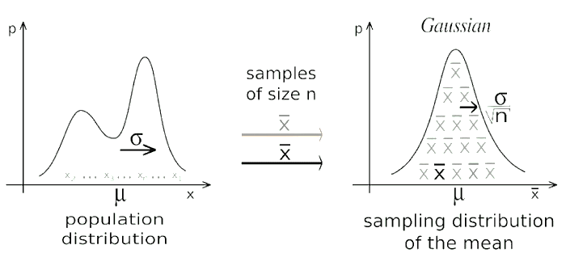

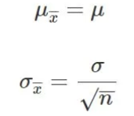

**Video tutorial — TileStats:** *The central limit theorem | Explained with a simple example*

https://www.youtube.com/watch?v=NTq0BO6pbbg

Distinguish the population distribution from the sampling distributions illustrated above.

**Sampling simulation — StatKey**

Choose a sample size, generate repeated samples and compare the population, individual samples and sampling distribution of the mean.

https://www.lock5stat.com/StatKey/sampling_1_quant/sampling_1_quant.html

[figure not shown]

### Simulating sampling variation and estimated standard error

[figure not shown]

#### Try this in R

- **Purpose:** Illustrate sampling variation and estimated standard error.
- **Before running:** `set.seed()` fixes the random sequence; `rnorm()` generates an artificial population. `replicate(1000,{...})` repeats the brace-enclosed calculations 1,000 times. `sample(size=30,replace=TRUE)` draws 30 observations with replacement. `mean()` and `sd()` summarise each draw; `sqrt(30)` converts sample SD to estimated SE. `[1,]` and `[2,]` select result rows. `hist(breaks=30)` displays the sample means; labels and `col` control presentation.

```r
# set.seed() makes this simulation reproducible; rnorm() creates the source's artificial population.
# replicate() repeats sampling with replacement; each column returns a mean and a sample-based SE.
set.seed(307312)
population <- rnorm(1000000, mean=50, sd=10)
# sample(replace=TRUE) draws independently with replacement; sqrt(30) is the SE denominator.
results <- replicate(1000, {
  x <- sample(population, size=30, replace=TRUE)
  c(sample_mean=mean(x), estimated_SE=sd(x)/sqrt(30))
})
# sd() and mean() compare simulated sampling spread and average estimated SE; agreement is illustrative.
# hist() uses 30 bins to display the 1,000 sample means; this simulation is not a mathematical proof.
c(SD_of_sample_means=sd(results[1,]), average_estimated_SE=mean(results[2,]))
```

```
  SD_of_sample_means average_estimated_SE
            1.840737             1.797712
```

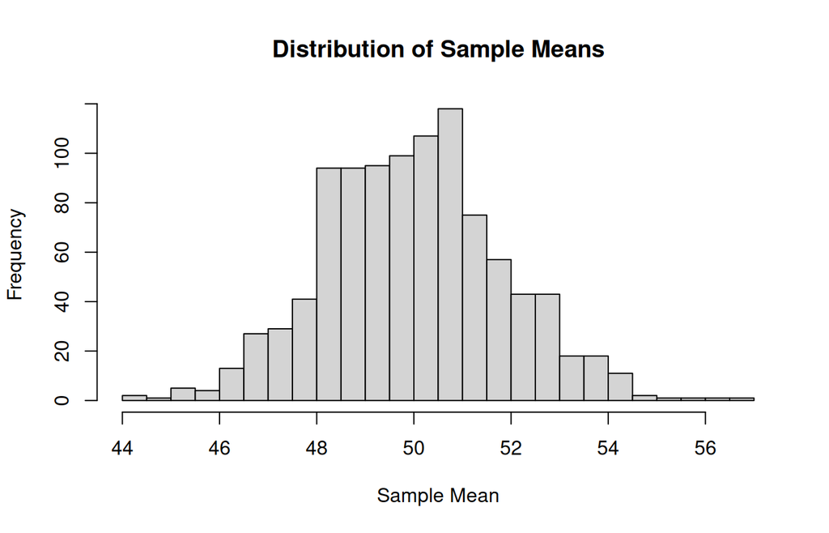

```r
hist(results[1,], breaks=30, col="#D4D4D4", main="Distribution of Sample Means", xlab="Sample Mean")
```

**Read the result:** The artificial population here is normal, so this illustrates sampling variation and SE rather than the CLT for a non-normal population. Compare the SD across sample means with the average estimated SE. Agreement illustrates the model; simulation is not a proof. Observations per sample and simulation repetitions are different quantities.

### Estimation in Statistics

- Often in statistics we’re interested in measuring population parameters.
- Two of the most common population parameters are:
  - Population mean: the mean value of some variable in a population (e.g. the mean height of males in the U.S.)
  - Population proportion: the proportion of some variable in a population (e.g. the proportion of residents in a county who support a certain law)
- Although we’re interested in measuring these parameters, it’s usually too costly and time-consuming to go around and collect data on every individual in a population in order to calculate the population parameter.
- Instead, **we typically take a random sample** from the overall population and use data from the sample to **estimate** the population parameter.

### Point Estimates

- Suppose we want to estimate the mean weight of a students in the university.
- Since there are thousands of students in the university, it would be extremely time-consuming and costly to go around and weigh each individual student.
- Instead, we might take a random sample of 50 students and use the mean weight of the students in this sample to estimate the true population mean.

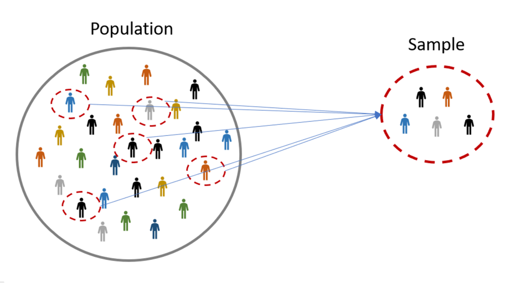

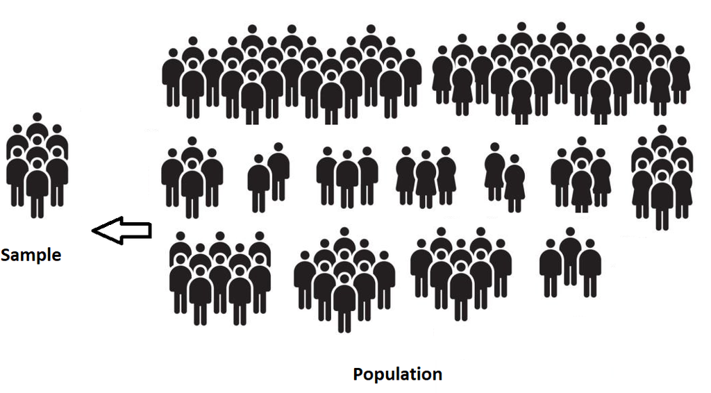

- In this case, the mean weight of the sample is called a Point Estimate for the true mean weight of the population.

### Point vs. Interval

- A point estimate is a single value estimate of a parameter. For instance, a sample mean is a point estimate of a population mean.
- An interval estimate gives you a range of values where the parameter is expected to lie.
- Both types of estimates are important for gathering a clear idea of where a parameter is likely to lie.

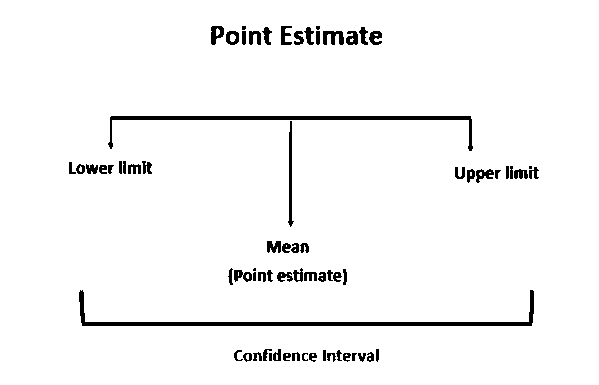

### Interval Estimates - Confidence Intervals

- The problem with the previous example is that the mean weight of students in the sample **is not guaranteed** to exactly match the mean weight of students in the whole population.
- For example, we might just happen to pick a sample full of low-weight students or perhaps a sample full of heavy students.
- To capture this uncertainty, we can create an Interval Estimate or a confidence interval around our point estimate**.**

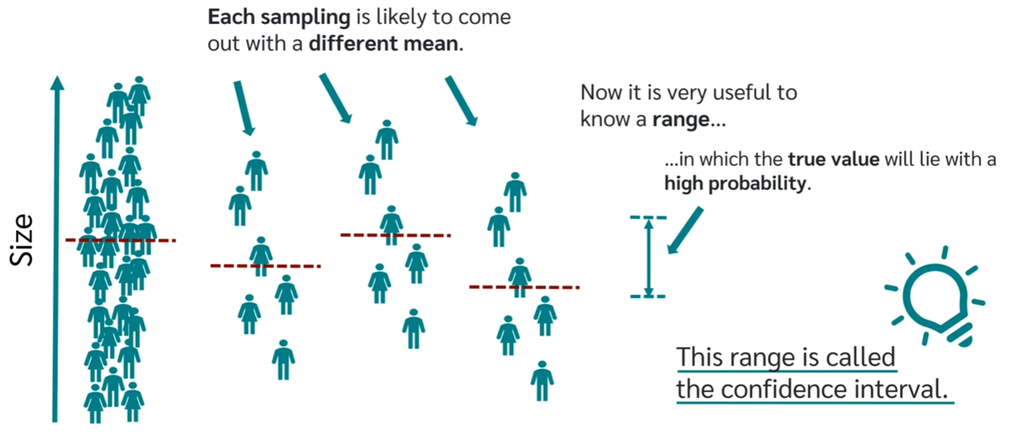

- The confidence interval gives us a range of values that are likely to contain the true population parameter.

### Inference: Turning the Sampling Model Around

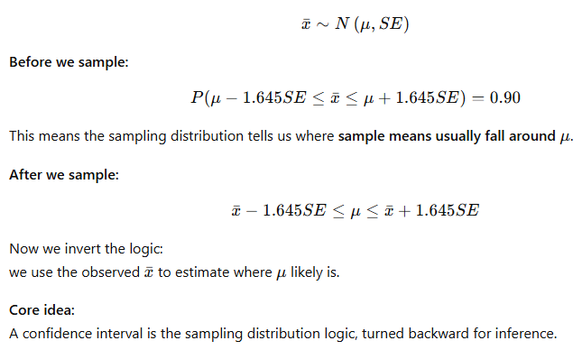

### The symmetry idea behind confidence intervals

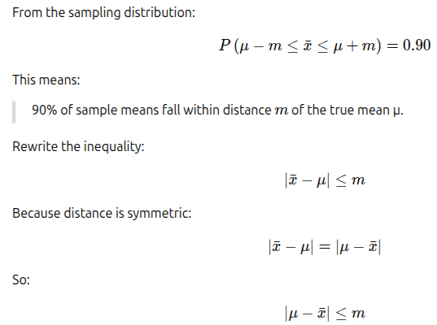

### From CLT to Confidence Intervals

A confidence interval uses a statistic’s sampling distribution to account for estimation uncertainty.

- With known population SD $\sigma$, an approximately normal sampling distribution gives $P(-1.96\leq(\bar{X}-\mu)/(\sigma/\sqrt{n})\leq1.96)\approx0.95$.
- Rearranging gives the 95% interval $\bar{x}\pm1.96\,\sigma/\sqrt{n}$.
- Here $\bar{x}$ is the observed sample mean, and 1.96 is the standard normal cutoff leaving 2.5% in each tail.
- Over repeated samples, approximately 95% of intervals constructed this way contain the fixed population mean $\mu$.
- If $\sigma$ is unknown, use $s$ and the appropriate t cutoff. The one-sample t interval is exact for independent normal observations and approximate more generally under suitable conditions.
- The CLT supports large-sample normal approximations for means; not every confidence interval is derived from the CLT.

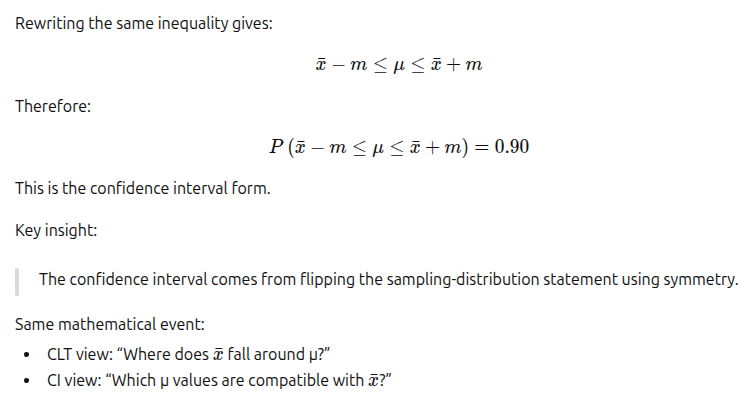

### The Significance Level Alpha (α) and The Confidence Level

- To compute the confidence interval, we need to define the Significance Level Alpha (*α)* or the Confidence Level.
- The two terms are related to each other according to the following equation:

**Confidence level= 1 –** *α*

- Common values for these notations are listed in the table

| **Alpha -** *α* | **5%** | **1%** |
| --- | --- | --- |
| **Confidence level** | **95%** | **99%** |
| **z-Value** | **1.96** | **2.58** |

### The Significance Level Alpha (α) and The Confidence Level

- The confidence level (e.g. 95%) means that if we collected 100 samples and created confidence intervals for each of these samples, we would expect that 95% of these confidence intervals will contain the true population parameter.
- It's important to note that this is a theoretical long-term proportion—it's about what we'd expect to happen over many repetitions of the same process, not a guarantee for any individual interval.

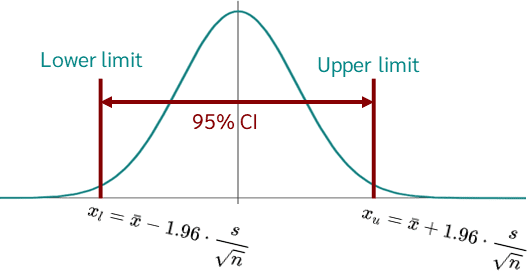

### Relationship Between Confidence Level and Significance Level in Statistics

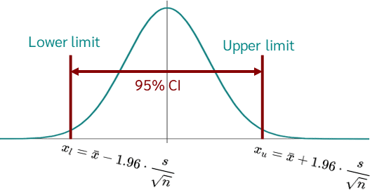

The **confidence level** and the **significance level (α)** are inverse and complementary concepts in statistical inference and hypothesis testing.

**Relationship:**

- The two are **complementary**, meaning that if you increase one, you decrease the other, and vice versa.
- A **higher confidence level** corresponds to a **lower significance level**, while a **lower confidence level** corresponds to a **higher significance level**.

**Formula:**

- Confidence Level=1−α

**Example:**

- A 95% confidence level means the significance level is 0.05 (α = 5%).
- A 99% confidence level means the significance level is 0.01 (α = 1%).

### Computing Confidence Intervals

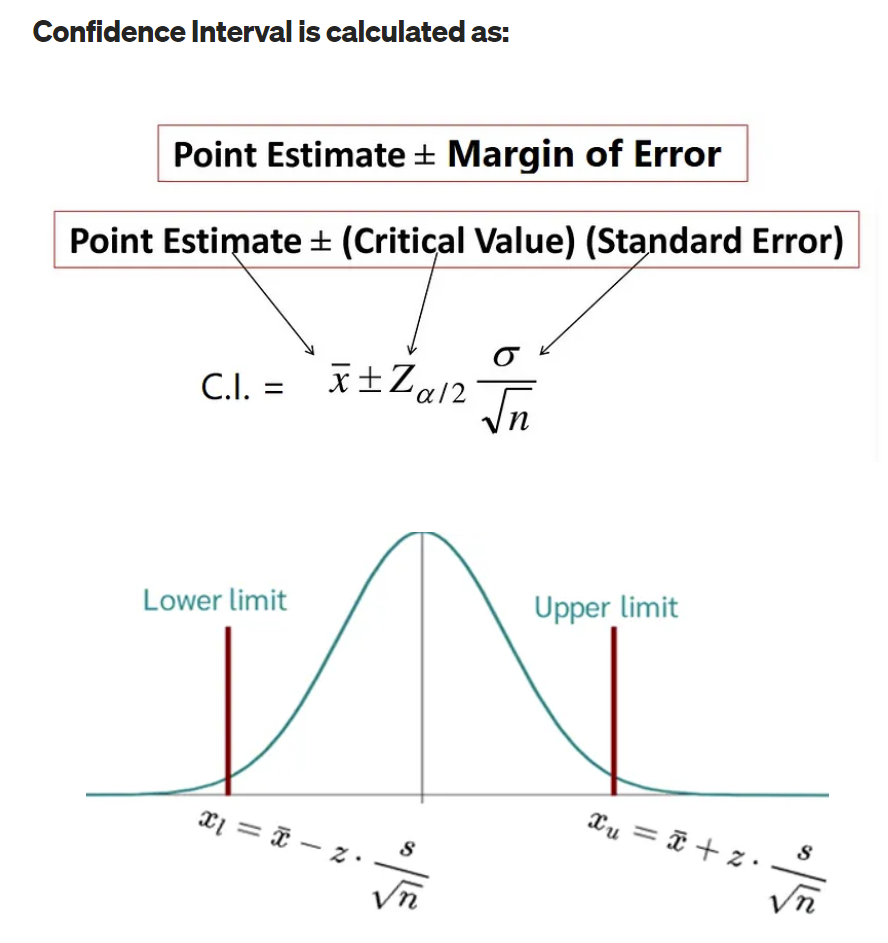

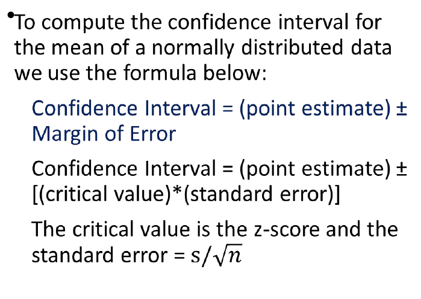

**Background reading — confidence intervals and margin of error**

Read about confidence levels, interval width and margin of error.

https://medium.com/@ashisharora2204/hypothesis-testing-confidence-interval-level-margin-of-error-39aa7c7ddcd2

[figure not shown]

### Confidence Intervals Example

Suppose we randomly collected a sample of students with the following information:

- Sample size n = 50
  - Sample mean weight x = 73.16 kg
  - Population standard deviation s = 8.63

What is the 90% confidence interval for the true population mean weight?

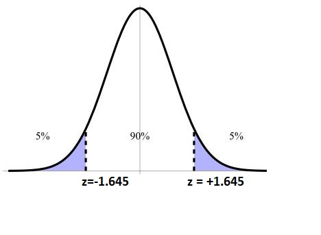

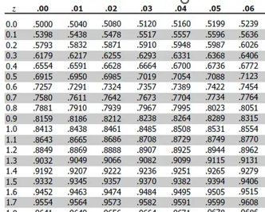

- To find the upper bound z-score for the 90% CI, we need to look for area 95% in the z table i.e. 90% + 5% (Look at the Figure)
- Therefore, according to the z-table, the upper bound z-score for the 90% Confidence Interval = 1.64 i.e. lower bound is -1.64.
- The Margin of Error = 1.64 * (8.63/√50) = ~2
- Therefore, the 90% CI = 73.16 ± 2 = [71.16, 75.16]

#### Try this in R

- **Purpose:** Calculate the 90% mean interval when population SD is treated as known.
- **Before running:** `qnorm(0.95)` gives the standard-normal cutoff leaving 5% above it. `sqrt(n)` converts the stated population SD to SE. `c(-1,1)` subtracts and adds the margin; n, xbar and sigma store the supplied summaries.

```r
# qnorm(0.95) gives the upper critical z for a central 90% interval; sigma=8.63 is treated as known.
# sqrt(n) scales population SD into SE; c(-1,1) constructs the lower and upper endpoints in kg.
n <- 50; xbar <- 73.16; sigma <- 8.63
xbar + c(-1,1)*qnorm(0.95)*sigma/sqrt(n)
```

```
[1] 71.15251 75.16749
```

**Read the result:** The two output values are the lower and upper limits in kg. This calculation depends on the slide’s stated known-population-SD setting.

### Confidence Intervals Example

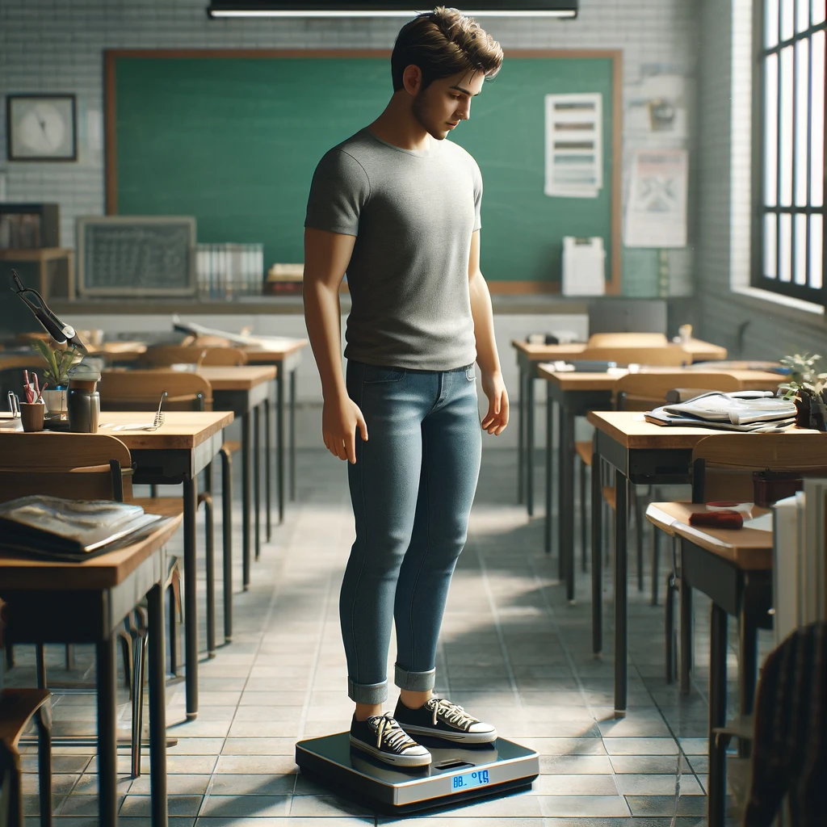

We interpret this 90% confidence interval as follows:

- The interval [71.16 kgs to 75.16 kgs] gives us a good estimate of where the mean lies, based on the collective information from our samples.
- The 90% means that if we estimate the population parameter and computed the confidence intervals 100 times, we expect that 90% of these intervals will contain our parameter.

### Solving Confidence Intervals using R

Suppose we randomly collected a sample of students with the following information:

- Sample size n = 50
  - Sample mean weight x = 73.16 kg
  - Sample standard deviation s = 8.63

What is the 90% confidence interval for the true population mean weight?

#### Try this in R

- **Purpose:** Calculate the 90% mean interval using the stated sample SD.
- **Before running:** `qt(p=0.95,df=49)` gives the central 90% t critical value for 50 observations. `sqrt(50)` appears in the SE; `c(-1,1)` gives lower and upper limits. The value 8.63 is estimated from the sample here.

```r
# qt(0.95,df=49) gives the central 90% t critical value when SD 8.63 is estimated from 50 observations.
# This t interval uses unknown population SD; it can differ from the original normal approximation.
73.16 + c(-1,1)*qt(0.95,df=49)*8.63/sqrt(50)
```

```
[1] 71.11383 75.20617
```

**Read the result:** Use t when population SD is unknown under suitable assumptions. This interval can differ from the preceding known-SD normal calculation.

### Transitioning to T-Distribution

- The T-distribution, like the normal distribution, is bell-shaped and symmetric but has heavier tails.
- This means there is more probability in the tails and less in the center compared to a normal distribution.
- The exact shape of the T-distribution depends on the degrees of freedom (df), which are related to the sample size.
- Degrees of freedom in the context of the T-distribution refer to the number of independent values in a calculation of a statistic that are free to vary.
- For a confidence interval, df is equal to the sample size (n) minus 1 (df = n - 1).
- As the sample size increases, the T-distribution approaches the normal Z-distribution.

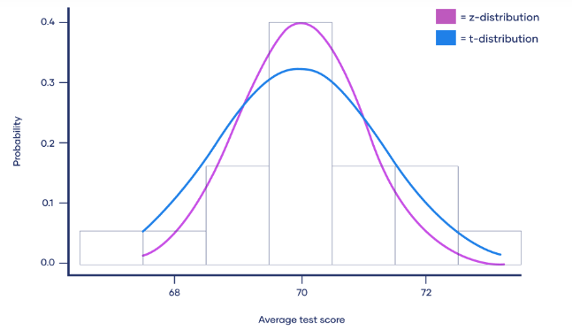

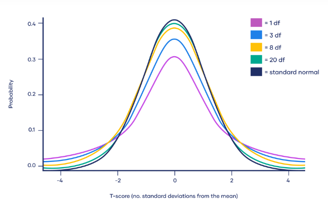

**Background reading — Student’s t distribution**

Reference material on the t distribution and its use in inference.

https://www.scribbr.com/statistics/t-distribution/

[figure not shown]

### When to use T-Distribution

- We can use the Z-distribution when the population variance is known or when our data is large enough (n > 30).
- However, real-world data often doesn't come with this information.
- In practice, the population variance is unknown, and we usually estimate the population variance using the sample variance, which introduces more variability into our statistics.
- The T-distribution accommodates this additional uncertainty and is especially useful for small sample sizes.
- The T-distribution often serves as a safer alternative because it accounts for the additional uncertainty from estimating the population variance.

### The T Table

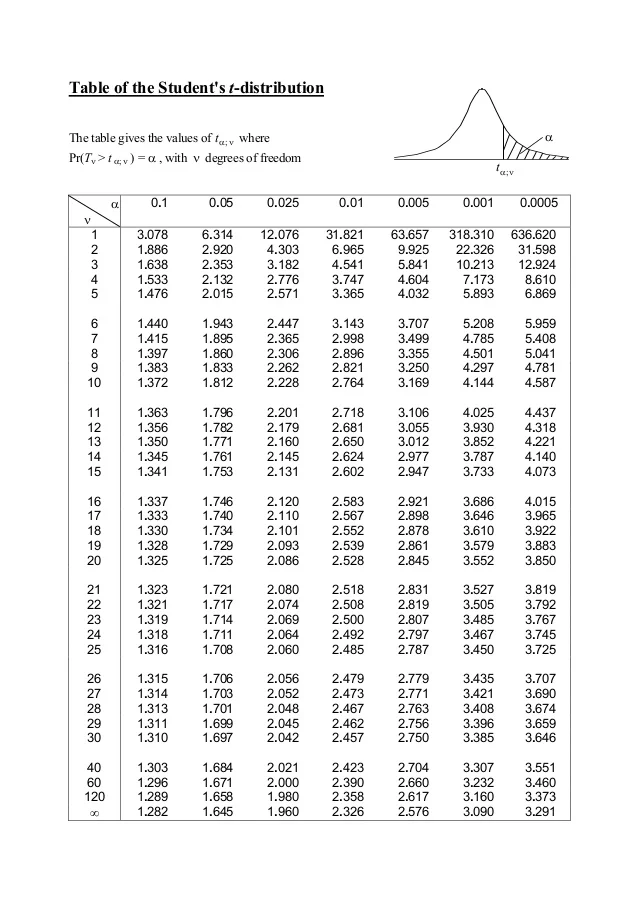

- The first column, denoted "v," lists the degrees of freedom.
- Degrees of freedom typically equal the sample size minus one (n-1) and relate to the number of independent values in a set of observations.
- The top row lists different significance levels (α), like the probabilities in z-table.
- The intersection of a row and column gives the t-value or t score, which is the cutoff point on the t-distribution.
- The table lists the areas (probability) on the right side, of the t-scores (opposite to the z-tables), therefore, to find a t scores for confident intervals we split α by 2 and look out the resulting value in the table.
- For example, to find the 90% confidence interval for a sample of 20 observations, we find α which is 1 - .9 = .1
- We split α by 2 = .1 / 2 = 0.05 and we lookout that value in the table = 1.729

### Confidence Intervals Using T-Distribution

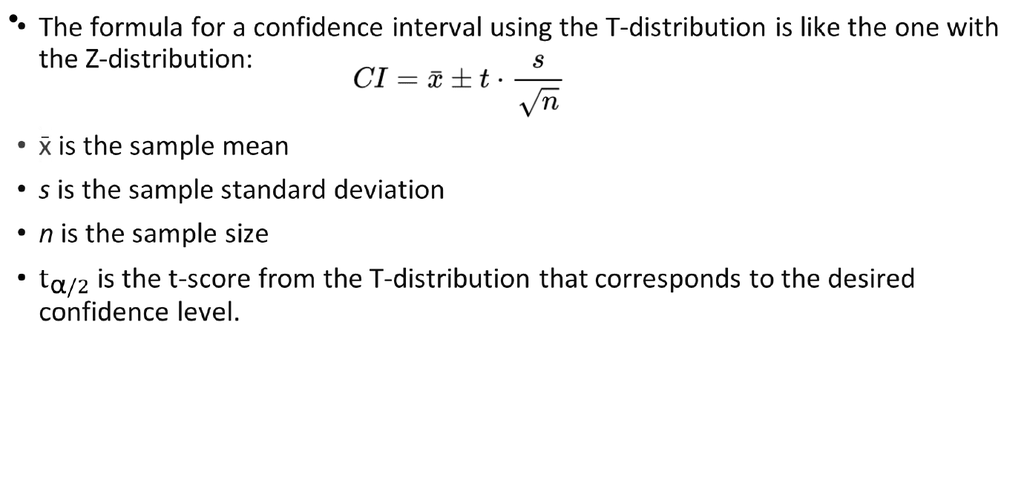

### Interval Estimates - Confidence Intervals

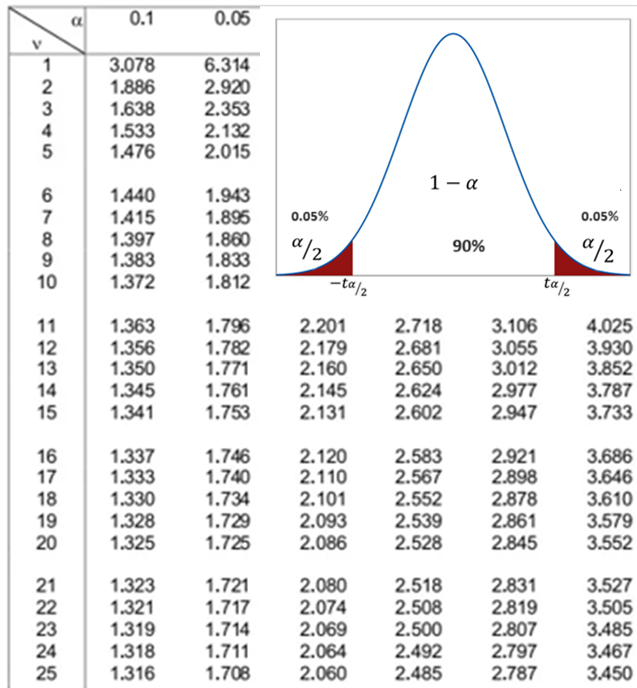

Suppose we randomly collected a sample of students with the following information:

- Sample size n = 20
  - Sample mean weight x = 72.94 kg
  - Samples standard deviation s = 8.3946

What is the 90% confidence interval for the true population mean weight?

- Confidence Interval 90%  *α* *= 1 - 0.9 = 0.1* ** *α/2 = 0.05*
- According to the t-table, the t-score for the 0.05 with df 20 – 1 = 19  t score = 1.729
- The Margin of Error = 1.729 * (8.3946/√20) = 3.25
- Therefore, the 90% CI = 72.94 ± 3.25 = [69.69, 76.19]

**What is the difference between the 90% Confidence Interval of the Z-Distribution and the 90% Confidence Interval of the T-Distribution?**

### Solving Confidence Intervals using R

Suppose we randomly collected a sample of students with the following information:

- Sample size n = 20
  - Sample mean weight x = 72.94 kg
  - Samples standard deviation s = 8.3946

What is the 90% confidence interval for the true population mean weight?

#### Try this in R

- **Purpose:** Calculate the 90% t interval for the sample of 20.
- **Before running:** `qt(0.95,df=19)` leaves 5% in the upper tail. Multiply it by sample SD 8.3946 divided by `sqrt(20)`. `c(-1,1)` places the resulting margin below and above mean 72.94.

```r
# qt() uses 19 degrees of freedom for n=20; the central 90% interval leaves 5% in each tail.
# The stated sample SD 8.3946 and mean 72.94 are in kg; no individual observations are invented.
72.94 + c(-1,1)*qt(0.95,df=19)*8.3946/sqrt(20)
```

```
[1] 69.69426 76.18574
```

**Read the result:** The limits are about 69.69 to 76.19 kg. A confidence interval concerns the population mean, not the range containing 90% of individual weights.

### Steps to Calculate the Needed Sample Size

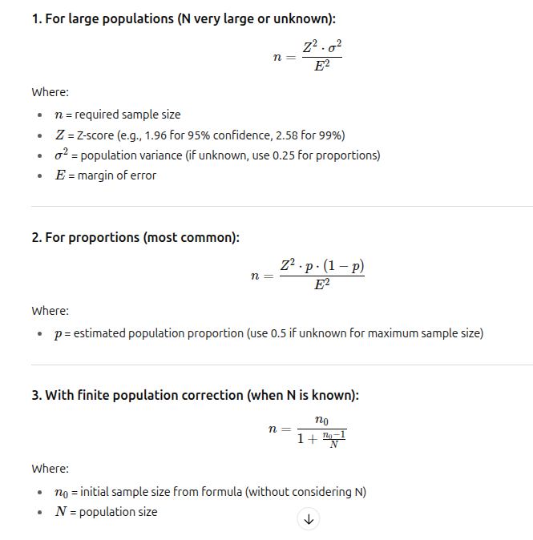

- **Define your research objectives and questions.**
- **Choose a significance level (α) and desired margin of error (E).**
- **Estimate population variability (σ),** or use conservative estimates if unknown.
- **Determine the population size (N).**
- **Select the type of sampling** (random or stratified).
- **Choose the statistical test or analysis** that will be applied.
- **Use a sample size formula or software tool** to calculate the required sample size.
- **Consider practical constraints** and adjust for potential non-response.
- **Conduct the study, analyze data, and interpret results.**

## 4.2 Hypothesis testing

### Content

Introduction to Hypothesis Testing

Business Examples

Significance Level – Alpha

Computing T-Statistic

Critical Value Approach vs P-Value Approach

Type I and Type II Errors

T-Test: Used for normally distributed data when the variance is unknown.

One-sample t-test: Tests the mean of a single group against a known mean.

Two-sample t-test: Compares the means of two dependent groups (paired test).

Two-sample t-test: Compares the means of two independent groups (variance assumed to be equal).

Two-sample t-test: Compares the means of two independent groups (variance assumed to be not equal).

Proportion Test: Compare sample proportion to a benchmark (e.g., open rate, conversion rate).

ANOVA (Analysis of Variance): Used to compare the means of three or more samples.

- One Way ANOVA
  - Two Way ANOVA

Chi-square test: Tests for relationships between categorical variables.

### Hypothesis Testing

**Hypothesis Testing** is a statistical method that uses sample data to evaluate a hypothesis about a population parameter.

A **hypothesis** is a claim about a population parameter that can be examined.

The purpose of hypothesis testing is to determine whether there is enough evidence in a sample of data to support a particular belief about a population.

Examples of claims that can be checked:

- Testing if a new marketing campaign increases customer engagement.
  - Checking whether a redesigned website improves conversion rates.
  - Evaluating if a new product packaging affects sales volume.
  - Determining if weekend promotions boost in-store foot traffic.
  - Assessing whether remote work impacts employee productivity.
  - Comparing customer satisfaction between two service locations.
  - Testing if a loyalty program increases repeat purchase rates.
  - Seeing if a price change affects total revenue.
  - Checking whether a new supplier leads to fewer product defects.
  - Measuring if training improves sales team performance.

### Business Related Examples in Hypothesis Testing

Category

Scenario

Type of Test

Detailed Experiment Design

Marketing

Testing if a new marketing campaign increases customer engagement.

Proportion

- Compare engagement rates (clicks, opens) between users exposed to the new vs. old campaign.
- Randomly assign at least 500 customers to two groups: one receiving the new campaign, one the old.
- Track engagement (clicks/opens) over a week.

Seeing if a promotional email improves open or click-through rates.

Proportion

- Compare open/click-through rates between two versions of an email.
- Send Version A to 1,000 customers and Version B to another 1,000.
- Ensure equal demographic spread.
- Compare open and click-through rates.

Measuring whether influencer partnerships drive more traffic to the site.

Mean

- Compare average daily website visits with and without influencer campaigns.
- Track daily website traffic for 30 days before and after the influencer campaign.
- Use rolling averages to minimize noise.

Evaluating if social media ads result in more conversions.

Proportion

- Compare conversion rates for users who saw the ads vs. those who did not.
- Randomly expose 5,000 users to social media ads while keeping a matched control group unexposed.
- Track conversion behavior over 7 days.

Sales & Revenue

Determining if a price change affects total revenue.

Mean

- Compare average revenue per user before and after price change.
- Collect revenue data for 4 weeks before and after price change.
- Use at least 1,000 transactions in each period to ensure reliability.

Testing whether bundling products increases average order value.

Mean

- Compare average order value for bundled vs. unbundled products.
- Assign 500 customers to view bundled product pricing and 500 to unbundled.
- Track order values across one sales cycle.

Assessing if offering free shipping improves purchase completion rates.

Proportion

- Compare checkout completion rates with and without free shipping.
- Split 2,000 checkout users evenly into groups with and without free shipping.
- Track completion rate within 24 hours.

Category

Scenario

Type of Test

Detailed Experiment Design

Operations

Checking whether a new supplier leads to fewer product defects.

Proportion

- Compare defect rates between products from the old vs. new supplier.
- Collect defect data from 1,000 units produced using the old supplier and 1,000 from the new.
- Monitor under similar production conditions.

Evaluating if a new production method reduces waste or error rates.

Mean

- Compare mean waste/error amounts using old vs. new methods.
- Run the production process using each method for a week, generating at least 500 measurements of waste or errors per method.

Determining if delivery time decreases with a new logistics provider.

Mean

- Compare average delivery times between the two providers.
- Record 1,000 delivery times for each provider across the same set of shipping regions and similar order types.

Customer Behavior

Testing if a loyalty program increases repeat purchase rates.

Proportion

- Compare proportion of returning customers with and without loyalty program.
- Track purchase frequency over 3 months for 1,000 loyalty program users and 1,000 non-users, matched by purchase history.

Seeing if a new mobile app design boosts daily active users.

Mean

- Compare average daily users before and after redesign.
- Monitor app usage data for 30 days before and after the redesign, using data from at least 5,000 active users.

Measuring if customer satisfaction differs after a policy change.

Mean

- Compare satisfaction ratings before and after the policy change.
- Survey at least 500 customers before and after the policy change or use NPS ratings from two equivalent time periods.

Human Resources

Assessing whether remote work impacts employee productivity.

Mean

- Compare average productivity scores of remote vs. in-office workers.
- Randomly select 200 remote and 200 in-office employees with similar roles. Track weekly productivity for 1 month.

Measuring if training improves sales team performance.

Mean

- Compare average sales figures before and after training.
- Analyze sales data from 100 employees for the 3 months before and after training. Normalize for seasonal trends.

Testing if flexible hours reduce employee turnover.

Proportion

- Compare turnover rates between employees with and without flexible hours. Track turnover across 1,000 employees with flexible hours and 1,000 without, matched on role and tenure, over a year.

### Key Concepts

- **Null Hypothesis (H₀):** A statement of no effect or no difference (usually we want to test this null state against a difference made by an intervention)
- **Alternative Hypothesis (H₁ or Ha):** What you want to prove – a statement of effect or difference.
- **Significance Level (α):** Probability of rejecting H₀ when it is actually true. Common choices: 0.05, 0.01.
- **p-value:** Probability of observing a result at least as extreme as the one obtained, assuming H₀ is true.
- **Test Statistic:** A value calculated from the sample to decide whether to reject H₀.

### The Null and The Alternative Hypothesis

When formulating a hypothesis test, we define two hypotheses: the null hypothesis (𝐻₀) and the alternative hypothesis (𝐻₁ or 𝐻ₐ).

These two hypotheses complement each other—only one of them can be valid.

For example, suppose a company claims that the average delivery time of its orders is 3 days.

To test this claim, the company defines the hypotheses as following:

**The Null hypothesis 𝐻₀:** The average delivery time **IS EQUAL TO 3 days.**

**The Alternative hypothesis 𝐻ₐ:** The average delivery time **IS NOT 3 days.**

Hypotheses are often expressed with symbols like this:

𝐻₀: μ = 3 days

𝐻ₐ: μ ≠ 3 days

Notice that the null hypothesis sets a **baseline** assuming no difference or effect—in this context, that the mean delivery time is not different from 3 days.

The burden of proof lies with the alternative hypothesis, which must show sufficient evidence that the average delivery time is different from 3 days.

### Choosing the Right Test

- **One-sample z-test or t-test**: Compare sample mean to a known value.

**Proportion test**: Compare sample proportion to a benchmark (e.g., open rate, conversion rate).

- **Two-sample t-test**: Compare means between two groups (e.g., control vs test).
- **Chi-square test**: Compare categorical variables (e.g., customer satisfaction vs region).
- **ANOVA Test:** Compare means between three or more groups.

### The Process

**Compare the Test Statistic to Critical Values**

If the calculated test statistic falls into the critical region, reject H₀.

Otherwise, fail to reject H₀.

**Calculate the P-Value (Alternative Approach)**

The p-value is the probability of observing a test statistic as extreme as, or more extreme than, the one obtained, assuming H₀ is true.

**Decision rule:**

If p ≤ α → reject H₀

If p > α → fail to reject H₀

**Make a Decision**

**Reject H₀:** Conclude there is evidence supporting Hₐ.

**Fail to reject H₀:** Conclude there is insufficient evidence to support Hₐ.

**Interpret Results**

Explain findings in the context of the research question.

Discuss practical significance and implications of the results.

**Formulate Hypotheses**

**Null hypothesis (H₀):** A statement of no effect or no difference. It represents the default assumption being tested.

**Alternative hypothesis (Hₐ):** The hypothesis you want to provide evidence for, suggesting there is an effect, difference, or relationship in the population.

**Choose a Significance Level (α)**

Select the probability of making a Type I error (rejecting H₀ when it is true).

Common choices: 0.05 (5%) or 0.01 (1%).

**Collect and Analyze Data**

Gather sample data relevant to your research question.

Perform an appropriate statistical analysis (e.g., t-test, chi-square test, ANOVA) depending on your study design.

**Calculate the Test Statistic**

Compute the test statistic based on sample data and H₀.

This quantifies how different the sample is from what is expected under H₀.

**Determine the Critical Region**

Identify the rejection region in the probability distribution of the test statistic.

If the statistic falls within this region, H₀ will be rejected.

### The Process in Brief

- **State** H₀ and Ha.
- **Choose** α (e.g., 0.05).
- **Collect data** and compute a test statistic.
- **Compute** the p-value.
- **Compare** p-value to α.
- **Decision:** Reject or fail to reject H₀.
- Note: We cannot we accept the null hypothesis, we can only reject it or fail to reject it.
- The basis for this testing process comes from logic.
- For example, if our null hypothesis = All students live in Amman, it will be challenging to check if all students live in Amman.
- On the other hand, it will be much easier to find just one student who does not live in Amman and therefore reject the null hypothesis.
- Rejecting is much easier that proving or accepting the hypothesis.

### More about Hypothesis Testing Core Concepts

Alpha value, The Test Statistic and Critical Values, P-Value, Type I and Type II Errors

### The Significance Level α

Before conducting the test, we need to set the significance level α.

The significance level is a measure of the strength of the evidence that must be present in our sample to reject the null hypothesis and conclude that the effect is statistically significant.

Typical significance levels are: α=0.1 (10%), α=0.05 (5%), α=0.01 (1%)

A lower significance level means that the evidence in the data needs to be stronger to reject the null hypothesis.

[figure not shown]

There is no "correct" significance level - it only states the amount of uncertainty of the conclusion.

A 5% significance level means that we expect to reject a true null hypothesis 5 out of 100 times (Type I Error).

### The Test Statistic

The test statistic is the value we compute based on the sample data that we collect.

The test statistic is used to decide the outcome of the hypothesis test.

We standardize test statistic using:

Z Standard Normal Distribution for large samples or when the variance is known.

The Student's T-Distribution (T) for small samples and the population variance is unknown.

### Computing the Test Statistic Dependence on our Knowledge about Variance

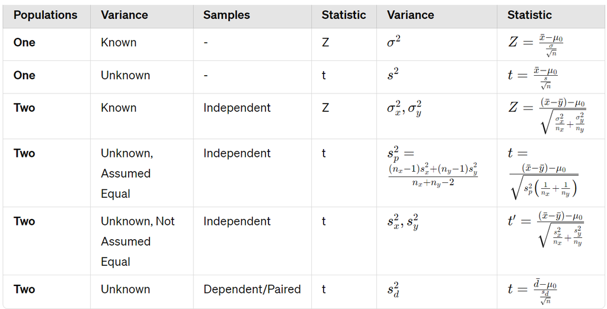

### The Critical Value and the p-Value Approach to Hypothesis Testing

To decide whether to reject the null hypothesis, a test statistic is calculated.

The decision is made based on the numerical value of that test statistic.

There are two approaches how to arrive at that decision: The critical value approach and the p-value approach.

**The critical value approach**

By applying the critical value approach, it is determined, whether the observed test statistic is more extreme than a defined critical value.

Therefore, the observed test statistic (calculated based on sample data) is compared to the critical value (a kind of cutoff value).

If the test statistic is more extreme than the critical value, the null hypothesis is rejected.

If the test statistic is not as extreme as the critical value, the null hypothesis is not rejected.

The critical value is computed based on the given significance level α and the type of probability distribution of the idealized model.

The critical value divides the area under the probability distribution curve in rejection region(s) and non-rejection region.

**Worked guide — critical-value and p-value approaches**

Compare critical regions and p-values in two-sided and one-sided hypothesis tests.

https://www.geo.fu-berlin.de/en/v/soga-r/Basics-of-statistics/Hypothesis-Tests/Introduction-to-Hypothesis-Testing/Critical-Value-and-the-p-Value-Approach/index.html

[figure not shown]

### The Critical Value Approach to Hypothesis Testing

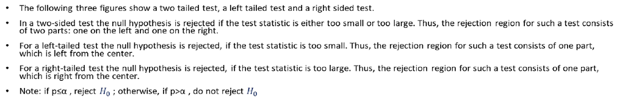

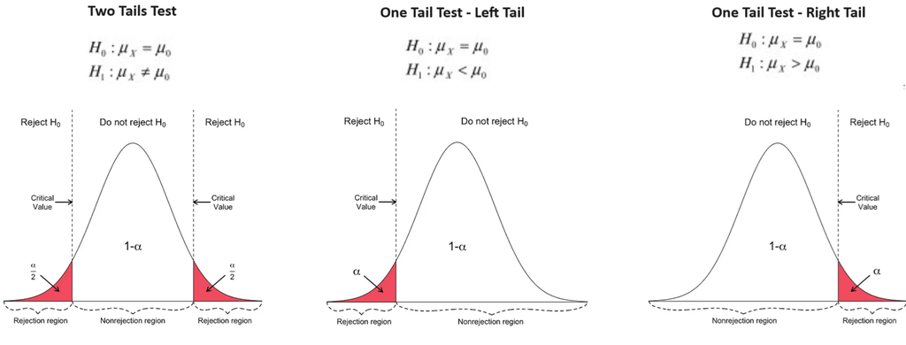

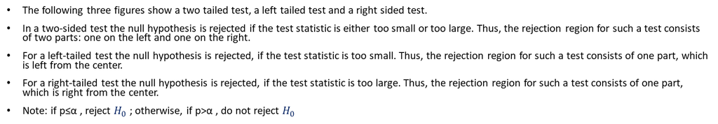

**Worked guide — critical-value and p-value approaches**

Compare critical regions and p-values in two-sided and one-sided hypothesis tests.

https://www.geo.fu-berlin.de/en/v/soga-r/Basics-of-statistics/Hypothesis-Tests/Introduction-to-Hypothesis-Testing/Critical-Value-and-the-p-Value-Approach/index.html

[figure not shown]